# Final Project - Visit Scotland

### Loading required libraries

```r
library(tidyverse)
library(here)
library(janitor)
```

### Loading the cleaned dataset

```r
activities_clean <- read_csv(here("clean_data/clean_activities.csv"))
clean_location   <- read_csv(here("clean_data/clean_location.csv"))
clean_transport  <-  read_csv(here("clean_data/clean_transport.csv"))
```

### Work done on data cleaning

- On all datasets, feature_code has been removed since it’s the only code for Scotland.
- Datacode column’s name has been changed on all dataset into year as it represent the year of the visitors.
- Measurement column also been removed from each dataset since we know its counting each visitor to represent these numbers.
- Check if any Na on all dataset.
- On all plots, I removed the "All" response. Since it does not give any insight to my plots and analysis.

### Business questions

There are too many business questions, I have divided the question into MPV and extensions due to time consuming

**MVP**

- What kind of tourism activity generates the highest income for Scotland?
- Which kind of activity generates the most visits to sites?
- What type of locations receive the most visits? What kinds of locations do people spend the most in?
- Is there a particular method of travel our visitors arrive by? Some of our locations are remote and not easily accessible by public transport, so this would be good information to have.
- How have general tourism rates changed over time?
- Is there any way to predict spending and visits for Visit Scotland?

**Extensions**

- Is there a particular key demographic of visitors we should be focusing on? Who spends the most? Who visits the most?
- When looking at regional tourism, what insights can we gain? Where are our visitors from? How do they differ in the money they spend, nights they spend in Scotland, or number of visits they do?
- What type of accomodation is most popular? Is there a difference by location?

# Q1. What kind of tourism activity generates the highest income for Scotland?

```r
highest_income <- activities_clean %>%
   filter(breakdown_of_domestic_tourism == "Expenditure", tourism_activity != "All") %>%
  group_by(tourism_activity) %>%
  summarise(expenditure_per_million_pounds  = sum(value))


highest_income %>%
   slice_max(expenditure_per_million_pounds)
```

| tourism_activity | expenditure_per_million_pounds |
| --- | --- |
| Went out for a meal | 13409 |

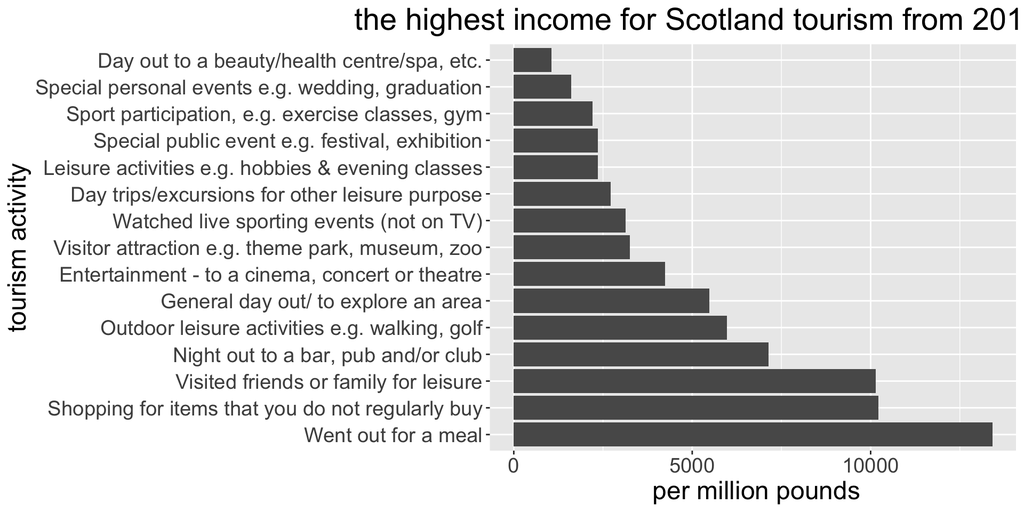

```r
highest_income %>%
   ggplot(aes(y = reorder(tourism_activity, -expenditure_per_million_pounds), x = expenditure_per_million_pounds)) +
  geom_bar(stat = "identity") +
    labs(
       title = "the highest income for Scotland tourism from 2013 to 2019",
          x = " per million pounds",
          y = "tourism activity"
  ) +
   theme(text = element_text(size = 18), plot.title = element_text(hjust = 0.5))
```

It's clear from the results above that the tourism spend their most money on restaurant by having their meal out.

# Q2. Which kind of activity generates the most visits to sites?

```r
most_visits <- activities_clean %>%
   filter(breakdown_of_domestic_tourism == "Visits", tourism_activity != "All") %>%
  group_by(tourism_activity) %>%
  summarise(activity_per_million_visits  = sum(value))

most_visits %>%
   slice_max(activity_per_million_visits)
```

| tourism_activity | activity_per_million_visits |
| --- | --- |
| Visited friends or family for leisure | 315 |

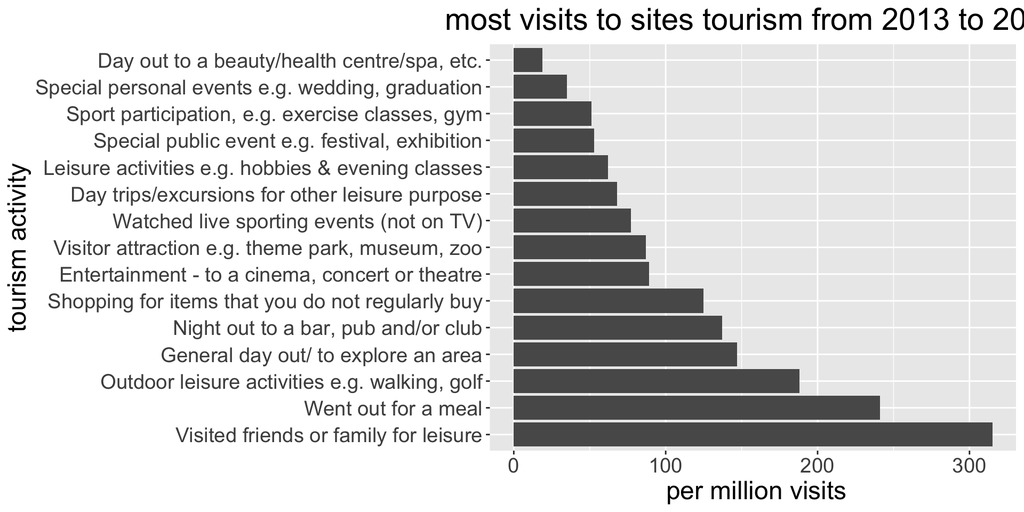

```r
most_visits %>%
   ggplot(aes(y = reorder(tourism_activity, -activity_per_million_visits), x = activity_per_million_visits)) +
  geom_bar(stat = "identity") +
    labs(
      title = "most visits to sites tourism from 2013 to 2019",
    y = "tourism activity",
    x = " per million visits"
  ) +
   theme(text = element_text(size = 18), plot.title = element_text(hjust = 0.5))
```

Visited friends or family for leisure are the top for tourism activity from the results above.

# Q3

## 3.1 What type of locations receive the most visits?

```r
most_visit_loca <- clean_location %>%
  filter(breakdown_of_domestic_tourism == "Visits", type_of_location_visited != "All areas") %>%
  group_by(type_of_location_visited) %>%
  summarise(most_visits_location = sum(value))

most_visit_loca %>%
  slice_max(most_visits_location)
```

| type_of_location_visited | most_visits_location |
| --- | --- |
| City/large town | 431 |

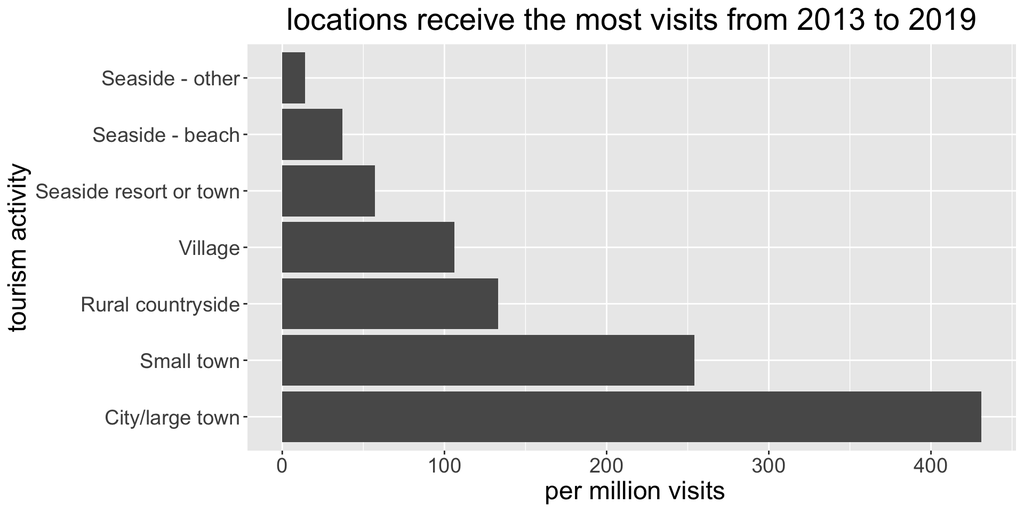

```r
most_visit_loca %>%
   ggplot(aes(y = reorder(type_of_location_visited, -most_visits_location), x = most_visits_location)) +
  geom_bar(stat = "identity") +
    labs(
       title = "locations receive the most visits from 2013 to 2019",
          x = " per million visits",
          y = "tourism activity"
  ) +
   theme(text = element_text(size = 18), plot.title = element_text(hjust = 0.5))
```

## 3.2 What kinds of locations do people spend the most in?

```r
most_spend_loca <- clean_location %>%
  filter(breakdown_of_domestic_tourism == "Expenditure", type_of_location_visited != "All areas") %>%
  group_by(type_of_location_visited) %>%
  summarise(most_spend_location = sum(value))

most_spend_loca %>%
  slice_max(most_spend_location)
```

| type_of_location_visited | most_spend_location |
| --- | --- |
| City/large town | 20497 |

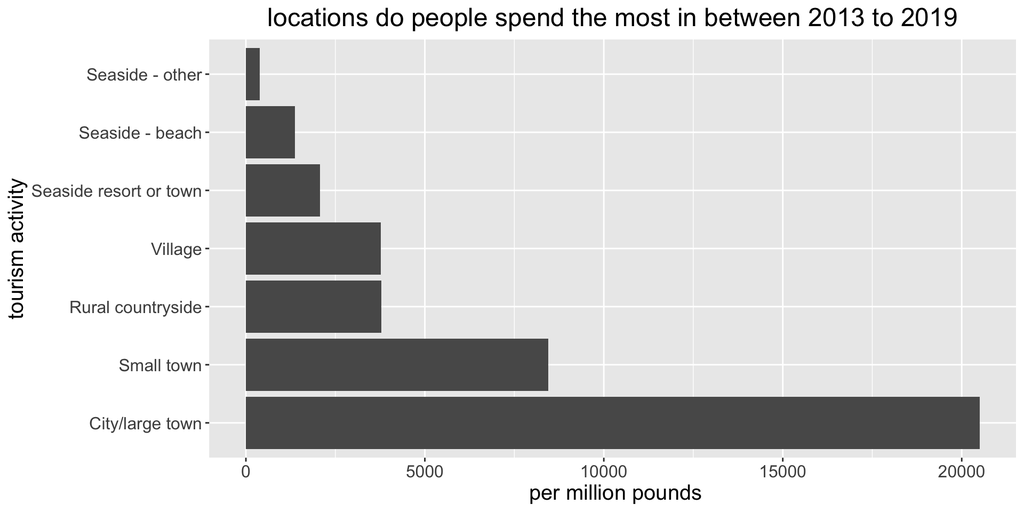

```r
most_spend_loca %>%
   ggplot(aes(y = reorder(type_of_location_visited, -most_spend_location), x = most_spend_location)) +
  geom_bar(stat = "identity") +
    labs(
       title = "locations do people spend the most in between 2013 to 2019",
          x = " per million pounds",
          y = "tourism activity"
   ) +
   theme(text = element_text(size = 15), plot.title = element_text(hjust = 0.5))
```

The plot below show the pattren of the most spend on locations visited during 2013 to 2019.

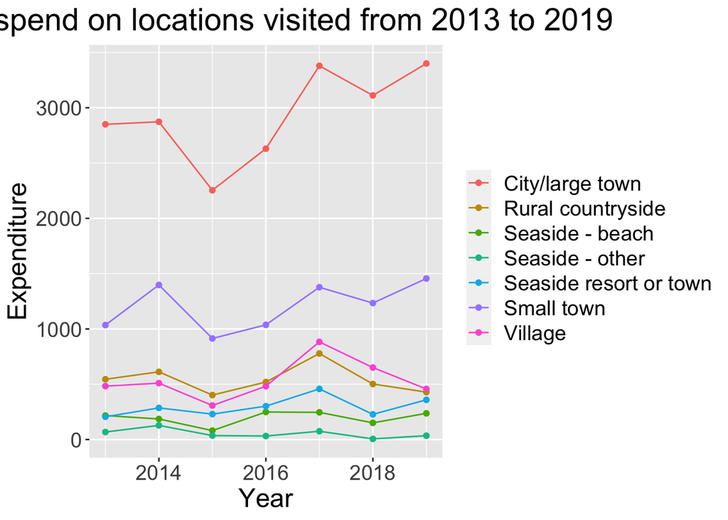

```r
clean_location %>%
  filter(breakdown_of_domestic_tourism == "Expenditure", type_of_location_visited != "All areas") %>%
  group_by(year,type_of_location_visited) %>%
  summarise(most_spend = sum(value)) %>%
  ggplot() +
  aes(x = year, y = most_spend, group = type_of_location_visited, colour = type_of_location_visited) +
  geom_point() +
   geom_line() +
      labs(
       title = "most spend on locations visited from 2013 to 2019",
          x = "Year",
          y = "Expenditure",
       legend.position = "yes"
  )  +
   theme(text = element_text(size = 18), plot.title = element_text(hjust = 0.5), legend.title = element_blank())
```

# Q4 Is there a particular method of travel our visitors arrive by?

```r
method_of_travel <- clean_transport %>%
  filter(!(method_of_travel %in% c("Other","All"))) %>%
  group_by(method_of_travel) %>%
  summarise(total = sum(value)) %>%
  arrange(desc(total))
method_of_travel
```

| method_of_travel | total |
| --- | --- |
| Car - own/friends/family | 21931.8 |
| Train | 5991.5 |
| Bus or Coach - Regular | 3502.7 |
| Taxi | 1353.7 |
| Walked | 1190.0 |
| Car - hired | 833.3 |
| Plane | 611.0 |
| Bus or Coach - Organised Tour | 500.8 |
| Caravan/Campervan | 121.8 |
| Boat/Ship/Ferry | 113.4 |

[output cut: 6 more lines]

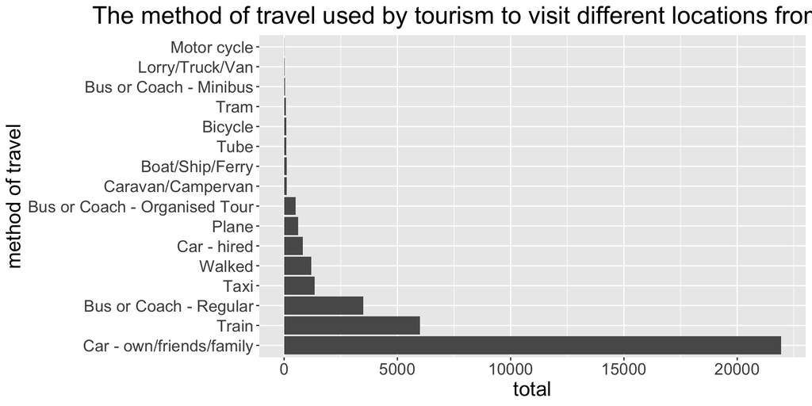

```r
method_of_travel %>%
   ggplot(aes(y = reorder(method_of_travel, -total), x = total)) +
  geom_bar(stat = "identity") +
    labs(
       title = "The method of travel used by tourism to visit different locations from 2013 to 2019",
          y = "method of travel"
  ) +
   theme(text = element_text(size = 18), plot.title = element_text(hjust = 0.5) )
```

joining the activities, location and transport dataset in order to see how the rates change over the years

```r
ctivities_location <- merge(activities_clean, clean_location, all = TRUE)
ctivities_location_trans <- merge(ctivities_location, clean_transport, all = TRUE)
```

# Q5 How have general tourism rates changed over time?

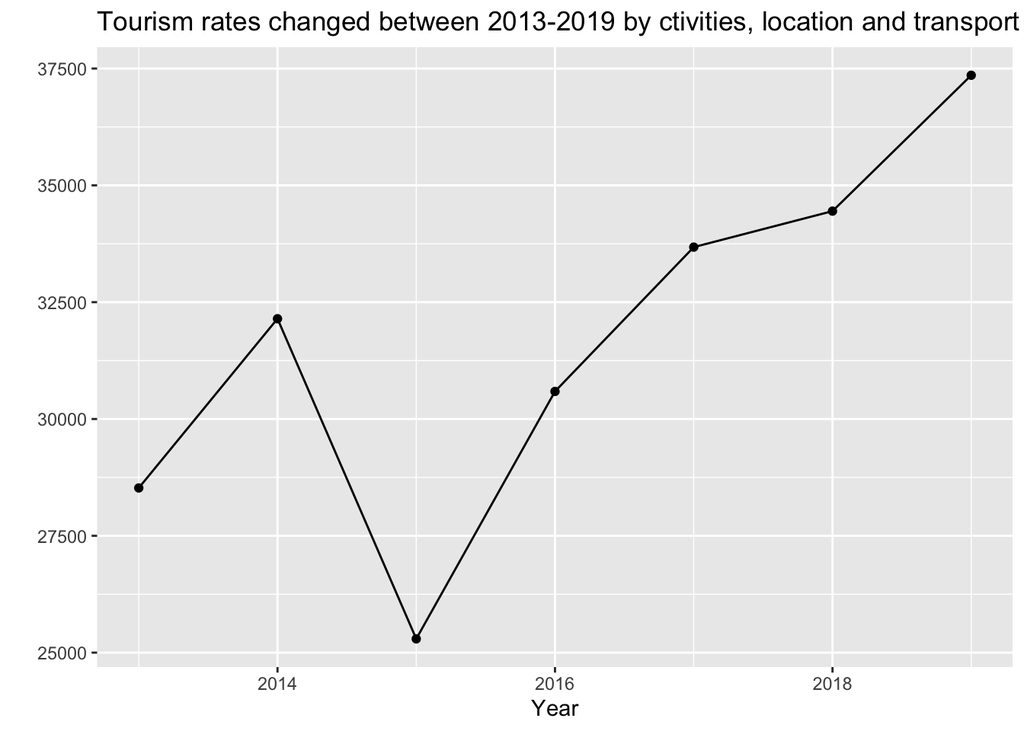

```r
ctivities_location_trans %>%
   group_by(year) %>%
  summarise(sum = sum(value)) %>%
  ggplot(aes(x = year, y = sum)) +
  geom_point() +
  geom_line() +
  labs(x = "Year",
       y = "",
       title = "Tourism rates changed between 2013-2019 by ctivities, location and transport")
```

The general picture of the pattern, it increases until 2019, however, it declines in 2015, and increases again in 2016.

# Conclusions and insights

- The most common activities for tourists in Scotland are eating out and visiting family and friends using the car as the most method of travel between different location. City and large town are the most spend and visited locations by tourism from 2013 to 2019.
- Regarding to the general tourism rates over years, we can see a sharp decline in 2015. However, since then, its increased until 2019.
- Since the majority of tourism travel by cars VisitScotland can be confident that any remote locations visitors can plan and go to these places.
- I advise VisitScotland that when they collect the data it would be great to have the months during the year this allow us to see the tourism activities during the year and which month is the busiest.